# COVID-19 Massachusetts Weekly Forecast Summary

[The COVID-19 Forecast Hub Team](https://covid19forecasthub.org/doc/) https://covid19forecasthub.org/

2022-09-01

# Background

This report provides a brief summary of the weekly ensemble forecast for Massachusetts from the [COVID-19 Forecast Hub](https://covid19forecasthub.org/). In collaboration with the US CDC, our team aggregates COVID-19 forecasts from dozens of teams around the globe. Typically on Wednesday of each week, a summary of the week’s forecasts from the COVID-19 Forecast Hub appear on the [official CDC COVID-19 forecasting page](https://www.cdc.gov/coronavirus/2019-ncov/covid-data/forecasting-us.html).

Every week, teams submit their forecasts to the COVID-19 Forecast Hub.

Each Tuesday, we combine the most recent forecasts from each team into a single “ensemble” forecast of reported COVID-19 deaths, hospitalizations and cases at the state and national level. At the moment, we only generate ensemble forecasts for up to four weeks into the future, as [the available evidence](https://www.medrxiv.org/content/10.1101/2021.02.03.21250974v1) suggests that models are less accurate at longer forecast horizons.

Weekly reports from the COVID-19 Forecast Hub can be found at [this page](https://covid19forecasthub.org/doc/reports/).

# COVID-19 Forecasts

Since the inputs to the ensemble model do not factor in changes in behavior or policy that could have an impact on short-term disease transmission (e.g. school openings or closures, new interventions, governmental policy shift, etc…), the ensemble model itself should not be looked to for specific answers to questions like “what will happen if or when schools open in 2 weeks” because most of the input models are not factoring in these changes. That said, the ensemble model has consistently shown strong predictive performance in predicting mortality, and very few of the many interventions put in place appear to have created dramatic changes in short-term disease transmission that would impact short-term trends in mortality.

This week, our ensemble combined forecasts for Massachusetts from 46 different models.

During periods of relative stability, models in general show broad agreement about the predicted trajectory of the outbreak. However, when there are steep surges or declines in cases or deaths, models often have quite different predictions for the upcoming weeks. The result is that there is increased uncertainty in the ensemble forecast, which can be seen as wider confidence intervals in the forecast visualization. You can explore the full set of models, including their forecasts for past weeks online at the [Forecast Hub interactive visualization](https://viz.covid19forecasthub.org/).

When interpreting probability of an increase, it’s important to note that the increase or decrease is relative to the location-specific recent observed incidence, which varies across locations.

### Deaths

For state-level death forecasts made over the last 6 weeks in Massachusetts for which observed data are now available, the 95% prediction intervals covered the truth 33% of the time, and the 50% prediction intervals covered the truth 0% of the time. The forecasts on average over the last 6 weeks predicted values that were higher than the observed data.

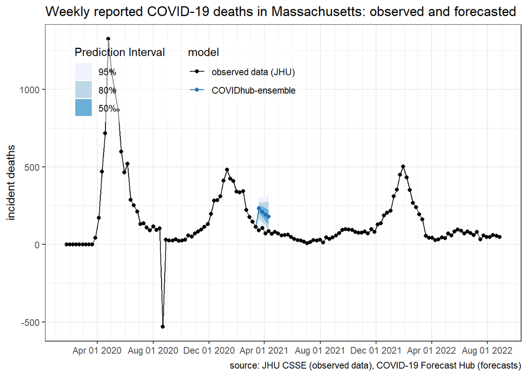

The sortable and searchable death table below shows the total number of reported COVID-19 deaths at the US level and state level for Massachusetts as of Saturday, March 13, 2021 (“Total COVID-19 Deaths”) as well as the rate of reported COVID-19 deaths in the population (standardized per 100,000 population) over the last two weeks and over the next two weeks.

[output not shown]

### Hospitalizations

As of September 28, 2021 the ensemble forecast only reports 14 day ahead forecasts for hospitalizations, due to persistent large inaccuracies observed when forecasting beyond that.

The ensemble model predicts that COVID-19 daily hospitalizations will be between 76 and 89 hospitalizations daily. However for March 29, 2021, the ensemble shows substantial uncertainty, with COVID-19 daily hospitalizations between 32 and 152 deemed possible.

For state-level hospitalization forecasts made over the last 6 weeks in Massachusetts for which observed data are now available, the 95% prediction intervals covered the truth 98% of the time, and the 50% prediction intervals covered the truth 60% of the time.

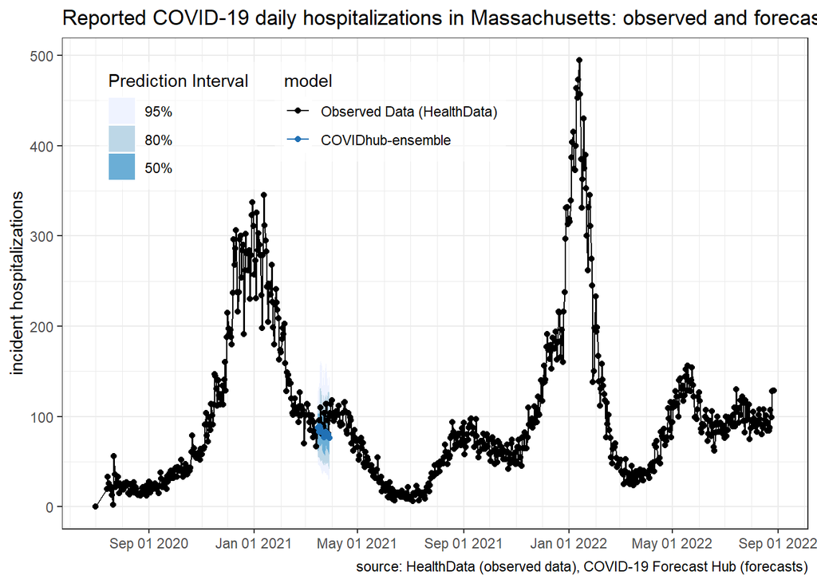

The sortable and searchable hospitalization table below shows the 7 day average hospitalization count and rate of reported COVID-19 hospitalization in the population (standardized per 100,000 population) over the last week (March 07, 2021 to March 13, 2021) and two weeks ahead (March 21, 2021 to March 27, 2021).

[interactive table not shown]

### Cases

As of September 28, 2021 the ensemble forecast only reports one-week ahead forecasts for cases, due to persistent large inaccuracies observed when forecasting beyond that.

For state-level case forecasts made over the last 6 weeks in Massachusetts for which observed data are now available, the 95% prediction intervals covered the truth 100% of the time, and the 50% prediction intervals covered the truth 50% of the time.

Figure 2: Weekly observed and forecasted COVID-19 cases. Observed data from [JHU CSSE](https://github.com/CSSEGISandData/COVID-19/tree/master/csse_covid_19_data/) and forecasts from the [COVID-19 Forecast Hub](https://covid19forecasthub.org/).

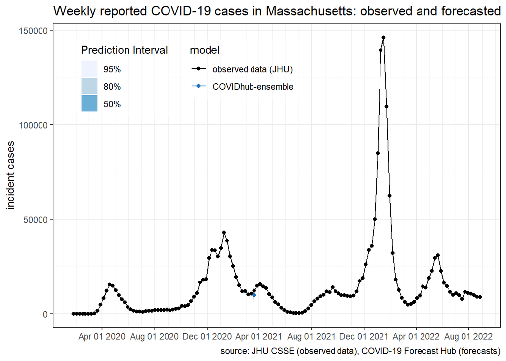

The sortable and searchable case table below shows the weekly case count and rate of reported COVID-19 case in the population (standardized per 100,000 population) over the last week (March 07, 2021 to March 13, 2021) and one week ahead (March 14, 2021 to March 20, 2021).

[interactive table not shown]

# Methods & Acknowledgement

This report was reproducibly and dynamically generated using RMarkdown. The code for the report can be found [here](https://github.com/reichlab/covid19-forecast-hub/tree/master/code/reports).